# Applied Bayesian Statistics - Assignment 2

Benjamin Cole - s3412349

12 September 2018

### Data and Packages

```r
packages <- c("tidyverse",
              "ggplot2",
              "rmarkdown",
              "knitr",
              "kableExtra",
              "purrr",
              "scales",
              "rjags",
              "runjags",
              "coda",
              "readr",
              "beepr")

lapply(packages, library, character.only=T)

source("DBDA2E-utilities.R")

# Data
PropertyPrices <- read_csv("Assignment2PropertyPrices.csv")

PropertyPrices$SalePrice <- as.numeric(PropertyPrices$SalePrice)
```

# **Part A**

### Model Diagram Parameters

```r
PropertyPrices %>% summarise("Mean Sale Price" = mean(SalePrice),
                             "Sale Price Var" = var(SalePrice),
                             "Sale Price SD" = sd(SalePrice),
                             "Min Sale Price" = min(SalePrice),
                             "Max Sale Price" = max(SalePrice),
                             "n Observations" = n()) %>%
  gather(key="Measure",
         value="Value") %>%
  kable(align="lr", "html",
        format.args = list(trim=F,
                           digits=1,
                           nsmall=1,
                           scientific=F,
                           big.mark=" ")) %>%
  kable_styling(full_width=F,
                bootstrap_options=)
```

| Measure | Value |
| --- | --- |
| Mean Sale Price | 609 360.2 |
| Sale Price Var | 262 475 685 684.1 |
| Sale Price SD | 512 323.8 |
| Min Sale Price | 200 000.0 |
| Max Sale Price | 7 000 000.0 |
| n Observations | 10 000.0 |

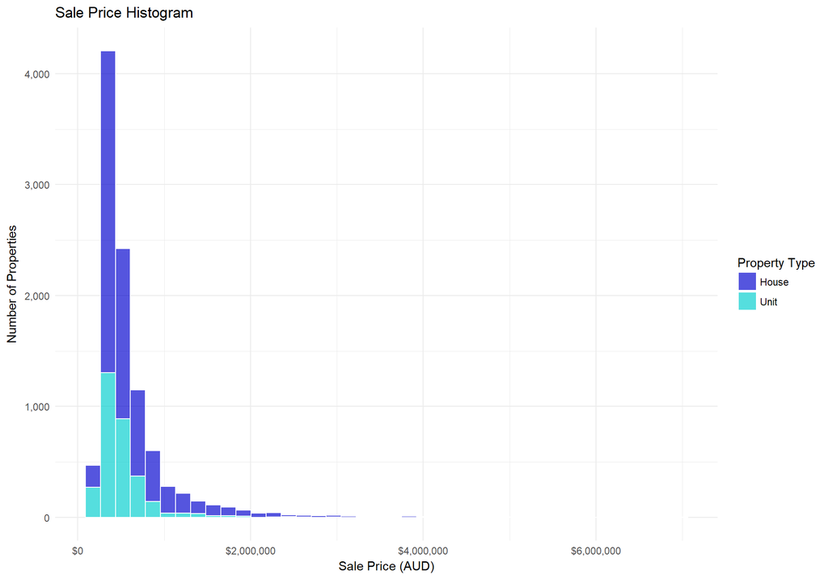

```r
# Sale price hist
ggplot(PropertyPrices, aes(x=SalePrice)) +
  geom_histogram(aes(fill=factor(PropertyPrices$PropertyType,
                                    labels=c("House", "Unit"))),
                 col="white",
                 bins=40,
                 alpha=2/3) +
  scale_x_continuous("Sale Price (AUD)",
                     labels=dollar) +
  scale_y_continuous("Number of Properties",
                     label=comma) +
  scale_fill_manual("Property Type",
                    values=c("blue3", "cyan3")) +
  ggtitle("Sale Price Histogram") +
  theme_minimal()
```

`SalePrice` is right-skewed and not normally distributed. However, as $n=10,000$, CLT can be assumed and that distribution of sampling means would be Gaussian. As such, the Bayesian model diagram is:

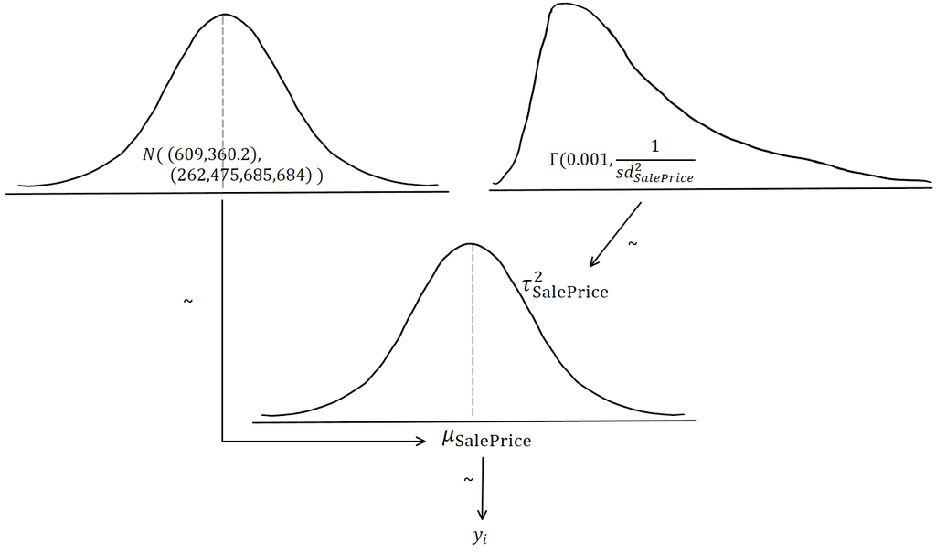

Model Diagram

### JAGS Data and Model blocks

```r
vectSalePrice <- PropertyPrices$SalePrice
nTotal <- length(vectSalePrice)

dataList <- list(
  vectSalePrice = vectSalePrice,
  nTotal = nTotal
)

var(vectSalePrice)
```

```
## [1] 262475685684
```

```r
modelString <- c("
model {
  # priors
  mu ~ dnorm(609360.2, tau)
  tau ~ dgamma(0.001, 1/(262475685684))

  # likelihood
  for (i in 1:nTotal) {
    vectSalePrice[i] ~ dnorm(mu, tau)
  }
}
"
)


writeLines(modelString, con="normJAGSmodel.txt")
```

### Compile Model and run Markov Chains

```r
jagsModel <- jags.model(file="normJAGSmodel.txt",
                        data=dataList,
                        n.chains=5,
                        n.adapt=150
                        )
```

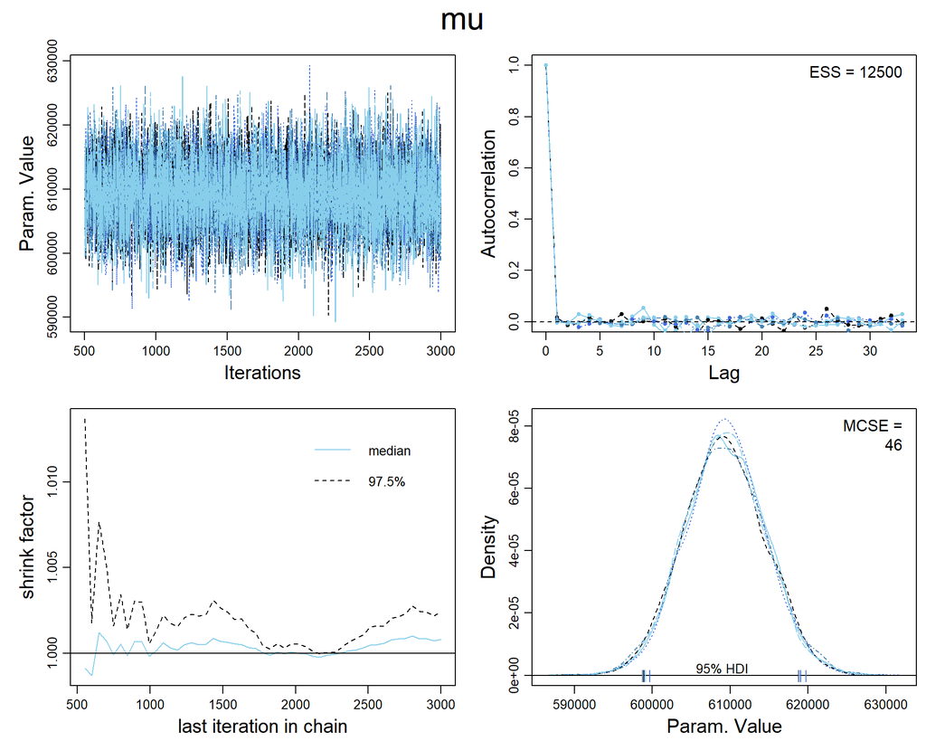

```
##      ESS     mean median     mode hdiMass hdiLow  hdiHigh compVal
## mu 12500 609322.2 609283 608403.9    0.95 599636 619749.5      NA
##    pGtCompVal ROPElow ROPEhigh pLtROPE pInROPE pGtROPE
## mu         NA      NA       NA      NA      NA      NA
```

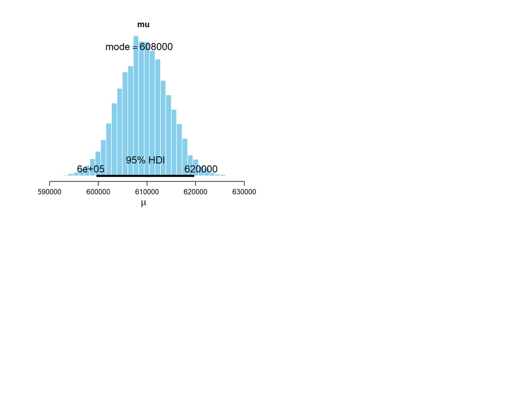

```r
update(jagsModel,
       n.iter=500)

codaSamples <- coda.samples(jagsModel,
                            variable.names=c("mu"),
                            n.iter=2500
                            )

beep(2)

# Display MCMC diagnostics
diagMCMC(codaObject=codaSamples,
         parName="mu")

# Display the posterior distribution of mu
plotPost(codaSamples[,"mu"],
          main="mu",
          xlab=bquote(mu)
         )
```

### Interpretation

#### Chain Accuracy

The *Effective Sample Size* is the same length of the chain $(ESS=12500)$ and the *Monte Carlo standard error* is somewhat low compared to $\bar{x}\approx 610,000$ at $(MCSE\approx46.2)$. Considering the *Effective Sample Size* adn the *Monte Carlo standard error*, it can be suggested that the chains are accurate represenations of the posterior probability distribution.

# **Part B**

### Regression Model

The following expert knowledge has been provided for the predictor variables of the data set, which allows for prior distributions to be defined: " * Area: Every m2 increase in land size increases the sales price by 90 AUD. This is a very strong expert knowledge. * Bedrooms: Every additional bedroom increases the sales price by 100,000AUD. This is a weak expert knowledge. * Bathrooms: There is no expert knowledge on the number of bathrooms. * CarParks: Every additional car space increases the sales price by 120,000AUD. This is a strong expert knowledge. * PropertyType: If the property is a unit, the sale price will be 150,000 AUD less than that of a house on the average. This is a very strong expert knowledge. "

These prior distributions will be used in the multiple linear regression equation $\mu=\beta_0+\beta_1X_1+\beta_2X_2+\beta_3X_3+\beta_4X_4+\beta_5X_5$, which can be modelled as:

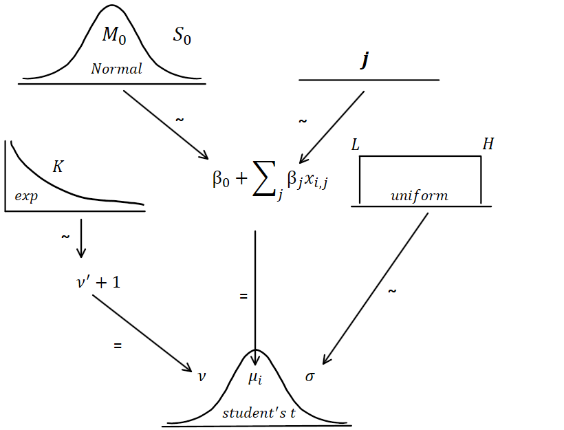

Generic Model Diagram

```r
# Bathrooms Range
min(PropertyPrices$Bathrooms)
```

```
## [1] 1
```

```r
max(PropertyPrices$Bathrooms)
```

```
## [1] 4
```

```r
# model {
#   for ( i in 1:nTotal ) {
#     # The first arrow defining the error/data distribution:
#     zy[i] ~ dt( mu[i] , 1/zsigma^2 , nu ) # Defines the t-distribution
#     # Define the linear regession model. Middle arrow in the second row:
#     mu[i] <- zbeta0 + zbeta1 * zx[i]
#   }
#
# # The left arrow in the second row:
# nu <- nuMinusOne+1
# nuMinusOne ~ dexp(1/29.0)
# # The right arrow in the second row:
# sigma ~ dunif( 1.0E-3 , 1.0E+3 )
# # The left arrow in the third row:
# zbeta0 ~ dnorm( 0 , 1/(10)^2 )
# # The right arrow in the third row:
# zbeta1 ~ dnorm( 0 , 1/(10)^2 )
# }
```